# Discrimination

### Background

The civil rights movement lasted from 1965-1969. During this time many racial discriminatory situations happened in many cities in states all over the U.S. Martin Luther King Jr. had an important part in helping black and white Americans who were impoverished. Having the Civil Rights Act and the Voting Rights Act in place really helped move segregation and racial discrimination to a whole new level. Adding some more pertinent information to this idea, the Massachusetts general court passed a law called the Racial Imbalance Act, which abolished segregation in public schools making it completely illegal. A survey was conducted where students at a certain university were asked the following question. “Do you think that some racial and religious groups should be prevented from living in certain sections of cities?” A summary of their response are recorded in the following table. The region of the United States that the student respondent was from was also recorded.

[Civil Rights](https://www.thoughtco.com/civil-rights-movement-timeline-from-1965-to-1969-45431)

[Racial Imbalance Act](https://bosdesca.omeka.net/exhibits/show/racial-imbalance_bps/racial-imbalance-act-1965)

| Region | *Agree* | *Undecided* | *Disagree* |
| --- | --- | --- | --- |
| East | 89 | 79 | 297 |
| Midwest | 118 | 130 | 350 |
| South | 241 | 140 | 248 |
| West | 37 | 59 | 197 |

Due to the information given above we need to make sure that the right test is being performed. The correct test for this specific question will be the Chi-Squared Test of independence.

#### Hypothesis

$$H_0: the~regions~and~the~responses~are~not~associated$$
$$H_a: the~regions~and~the~response~are~associated$$
$$Level~of~Significance:0.05$$

```r
discrim <- matrix(c(89,79,297,118,130,350,241,140,248,37,59,197), ncol = 3, byrow = T)
colnames(discrim) <- c("Agree","Undecided","Disagree")
rownames(discrim) <- c("East","Midwest","South","West")
```

### Analysis

After running the Chi-Squared test the results we acheived are seen below with a test statistic, Degrees of Freedom, and a P-value.

```r
chis.discrim <- chisq.test(discrim)
pander(chis.discrim)
```

Pearson’s Chi-squared test: `discrim`

| Test statistic | df | P value |
| --- | --- | --- |
| 125 | 6 | 1.476e-24 * * * |

As you can see our requirements are met; all expected counts must be greater than 5 and as you can see in the chart below all are well above 5.

```r
pander(chis.discrim$expected)
```

|  | Agree | Undecided | Disagree |
| --- | --- | --- | --- |
| **East** | 113.6 | 95.58 | 255.8 |
| **Midwest** | 146.1 | 122.9 | 329 |
| **South** | 153.7 | 129.3 | 346 |
| **West** | 71.59 | 60.22 | 161.2 |

Below We have a barplot of those responses from four different sections of the U.S. Each section was required to respond as “agree”, “undecided”, or “disagree”.

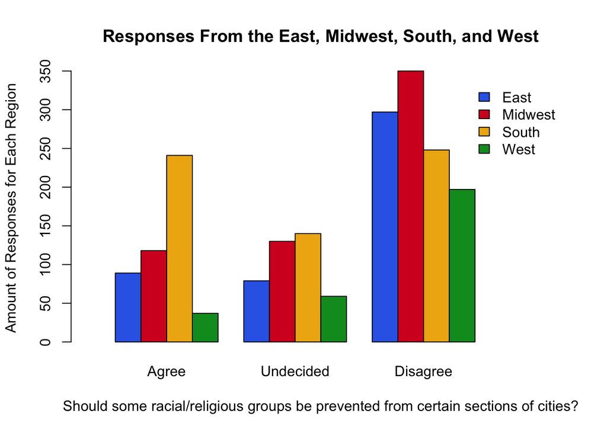

```r
barplot(discrim, beside = TRUE, legend.text = TRUE, args.legend=list(bty="n"), main = "Responses From the East, Midwest, South, and West", ylab = "Amount of Responses for Each Region", xlab = "Should some racial/religious groups be prevented from certain sections of cities?", xlim = c(0,18), col = c("#3369E8", "#D50F25", "#EEB211", "#009925"))
```

From looking at the graph you can see that the taller bars are mainly in the “disagree” response. There were several people who were undecisive and some who said they agreed to the original question. We can definitely get some useful information just by looking at this graph.

### Interpretation

The residual table below will help give more information that cannot be observed from the barchart above. These numbers will show how the observed counts differ from the expected counts.

```r
pander(chis.discrim$residuals)
```

|  | Agree | Undecided | Disagree |
| --- | --- | --- | --- |
| **East** | -2.309 | -1.696 | 2.575 |
| **Midwest** | -2.326 | 0.6392 | 1.159 |
| **South** | 7.043 | 0.9423 | -5.27 |
| **West** | -4.088 | -0.1577 | 2.821 |

Thee residual numbers above show how the oserved counts differ from the expected counts. The P-value we acheived before was a 1.476e-24. We will clearly reject the null hypothesis and confirm the alternative that the region and response are associated. We found that in the South the Pearson Residual of 7.043 shows that the obeserved count for students that agreed was higher than the expected count. The Pearson Residual of -5.27 shows that the observed count for students that disagreed was lower than the expected count.